# Der Effekt von Earnings-Conference Calls am Aktienmarkt

# Motivation

Earnings Conference Calls sind zentrale Informationsereignisse in Finanzmärkten. Hier kommuniziert das Management direkt mit Investoren und Analysten über die aktuelle Geschäftslage und Zukunftsaussichten. Die finanzwirtschaftliche Forschung zeigt, dass diese Calls erhebliche Kursbewegungen auslösen können - doch die zugrundeliegenden Mechanismen sind noch nicht vollständig verstanden.

Während traditionelle Finanztheorie von effizienten Märkten ausgeht, die alle verfügbaren Informationen sofort verarbeiten, zeigen empirische Studien, dass die Art der Kommunikation und das Sentiment der Aussagen eigenständige Erklärungskraft für Aktienkursreaktionen besitzen. Diese Erkenntnisse haben direkte praktische Relevanz: Banken nutzen Sentiment-Analysen für algorithmische Handelsstrategien, Hedge Fonds entwickeln systematische Ansätze zur Textauswertung, und Asset Manager integrieren qualitative Informationen in ihre Bewertungsmodelle.

In diesem Projekt kombinieren Sie Event Studies - eine etablierte Methode der empirischen Finanzforschung zur Messung von Informationseffekten - mit modernen Large Language Models zur systematischen Textanalyse. Sie untersuchen, ob und wie sich qualitative Aussagen des Managements in quantifizierbaren Marktreaktionen niederschlagen, und lernen dabei sowohl die methodischen Grundlagen der Kausalitätsidentifikation als auch den praktischen Umgang mit KI-gestützten Finanzanalysen kennen.

# Event-Study-Methodik und theoretische Diskussion

1. Lesen Sie das Kapitel [“Event Studies” in Huntington-Klein (2021)](https://theeffectbook.net/ch-EventStudies.html) und beantworten Sie die folgenden Fragen dazu:

Kann eine Eventstudie helfen, den kausalen Effekt eines Earnings Conference Calls auf die Aktienrendite eines Unternehmens zu identifizieren? Gehen Sie bei der Beantwortung dieser Frage insbesondere auf die nachfolgenden Punkte ein:

- Welche Art von Variation nutzt eine Eventstudie zur Identifikation des Effekts?
- Welche Voraussetzung(en) müssen erfüllt sein, damit die Eventstudie eine gültige Kausalschätzung liefert?
  - Was bedeutet das “Joint-Test Problem” in diesem Kontext?

Eine Eventstudie kann grundsätzlich dazu genutzt werden, den kausalen Effekt eines Earnings Conference Calls (ECC) auf die Aktienrendite eines Unternehmens zu identifizieren. Dabei basiert die Methodik auf einer spezifischen Art von Variation: der zeitlichen Variation rund um ein klar definiertes Ereignis. Die Grundidee besteht darin, die tatsächliche Rendite der Aktie im engen zeitlichen Umfeld des Events – also etwa am Tag des Conference Calls – mit einer erwarteten „normalen“ Rendite zu vergleichen, die sich aus einem Referenzmodell (wie dem Marktmodell oder CAPM) ergibt. Die Differenz zwischen beobachteter und erwarteter Rendite wird als „abnormale Rendite“ bezeichnet und dient als Schätzer für den Effekt des Events.

Damit eine Eventstudie eine gültige Kausalschätzung liefert, müssen jedoch mehrere zentrale Voraussetzungen erfüllt sein. Erstens darf es im betrachteten Eventfenster keine anderen simultanen Ereignisse geben, die ebenfalls den Aktienkurs beeinflussen könnten. Nur wenn der Conference Call das einzige relevante neue Ereignis ist, kann ein beobachteter Kurseffekt kausal darauf zurückgeführt werden. Zweitens setzt die Methode voraus, dass die Kapitalmärkte effizient sind, also neue Informationen sofort und vollständig in den Preisen reflektieren. Unter dieser Annahme lassen sich die Effekte des Earnings Calls zeitlich isoliert messen. Drittens muss das zur Schätzung der erwarteten Rendite genutzte Modell korrekt spezifiziert sein. Wenn das Modell fehlerhaft ist, etwa durch falsche Annahmen über die Marktrendite oder Unternehmensspezifika, kann die abnormale Rendite verzerrt sein.

In diesem Zusammenhang ergibt sich ein fundamentales Problem der Eventstudien, das sogenannte „Joint-Test Problem“. Es beschreibt, dass man beim Testen eines Events nicht nur überprüft, ob das Ereignis einen Effekt hatte, sondern gleichzeitig auch, ob das Modell für die erwartete Rendite korrekt ist. Ein signifikanter Effekt kann also entweder bedeuten, dass das Event tatsächlich einen Einfluss hatte – oder dass das zugrunde liegende Modell fehlerhaft ist. Da sich diese beiden Aspekte empirisch nicht sauber trennen lassen, handelt es sich immer um einen gemeinsamen Test zweier Hypothesen: der Nullhypothese „kein Eventeffekt“ und der Nullhypothese „Modell korrekt“. Dieses methodische Dilemma muss bei der Interpretation der Ergebnisse stets mitgedacht werden.

Insgesamt kann eine Eventstudie also unter den richtigen Annahmen eine plausible Schätzung eines kausalen Effekts liefern, etwa des Einflusses eines Earnings Conference Calls auf die Aktienrendite. Entscheidend ist, dass die Voraussetzungen – insbesondere die Abwesenheit anderer Einflüsse im Eventzeitraum und die Modellvalidität – möglichst gut erfüllt sind.

# Daten und Datenaufbereitung

## Finanzmarktkennzahlen

2. Sie sollten in einem ersten Schritt Finanzkennzahlen aus Datastream herunterladen. Insbesondere sollten Sie den Return Index (RI) und die Total Assets (WC02999) für alle Firmen im Euro Stoxx 600 Technology Index ( wir haben Ihnen die RIC Kürzel in der Readme bereitgestellt ) vom 01.01.2020 bis heute extrahieren.

Bitte laden Sie für den Return Index tägliche Daten herunter und für die Total Assets Quartalsdaten. Weiterhin sollten Sie den Total Return Index (RI) des Euro Stoxx 600 (RIC = .STOXX) herunterladen (auch tägliche Daten). Bitte achten Sie darauf alle Daten **in Euro** herunterzuladen.

Achten Sie darauf die RIC als eindeutige Identifikationskennung in ihren Datensatz aufzunehmen.

Das Institut für Finanzwirtschaft der Universität Ulm hat einen ausführlichen [Guide zu Datastream](https://www.uni-ulm.de/fileadmin/website_uni_ulm/allgemein/Update_Introduction_Datastream_May_2025.pdf) erstellt, der Ihnen beim Download der Daten sicherlich helfen kann.

Die Universität Ulm stellt für den Download Remote-PCs zur Verfügung, auf die Sie sich von daheim aus einloggen können. Bitte buchen Sie sich hier einen Slot um Zugriff auf diese PCs zu erhalten: https://www.uni-ulm.de/mawi/iof/lehre/proposals-for-theses/datastream-and-workspace/

Sie sollten ihre Daten in Excel herunterladen und in ihrem Projekt im Unterordner `data` abspeichern.

*Hinweis 1:* Es empfiehlt sich zwei Tabellenblätter im Excel File anzulegen, eines für die täglichen Daten und eines für die Quartalsdaten

*Hinweis 2:* Datastream ist eine Datenbank, die Kennzahlen zur Finanzlage von börsennotierten Unternehmen weltweit beinhaltet. Die Lizenzen zu Datastream an der Universität Ulm werden von der Studienkommission Wirtschaftswissenschaften und der LBBW bezahlt und die Datenbank steht allen WiWi-Studierenden frei zur Verfügung. [Nähere Informationen zu Datastream finden Sie hier](https://www.uni-ulm.de/mawi/iof/lehre/proposals-for-theses/datastream-and-workspace/) (Bitte beachten: Sie müssen im Uninetz (z.B. über VPN) eingeloggt sein um die Informationen zu sehen und um sich auf die Remote-PCs loggen zu können).

*Hinweis 3:* Bei den Total Assets müssen Sie immer das Enddatum des vorherigen Jahres nehmen für den Download, d.h. Start Date wäre 31.12.2019

3. Lesen Sie die Excel Datei, welche Sie in Aufgabe 2 erstellt haben, in R ein. Achten Sie darauf, dass diese Daten tidy und richtig formatiert sind. Joinen Sie die täglichen Daten mit den Quartalsdaten für die relevanten Firmen. Die Quartalsdaten zählen für das komplette Quartal zu dem diese hinzugemerged wurden.

Setzen Sie sich mit den Aktienkursen auseinander und beantworten folgende Fragen: - Sie wollen in Aufgabe 4 *Renditen* berechnen, warum sollten Sie Daten zum “Total Return Index” und nicht dem “Price” oder “Unadjusted Price” herunterladen? Schauen Sie sich zur Klärung dieser Frage den [Guide der Uni Ulm zu Datastream](https://www.uni-ulm.de/fileadmin/website_uni_ulm/allgemein/Update_Introduction_Datastream_May_2025.pdf) genauer an. Diesen Guide sollten sie auch für den Download der Daten heranziehen.

*Hinweis:* In dem tidy Datensatz sollten Sie eine Spalte mit dem Unternehmensidentifier (RIC), eine mit dem Datum und eine mit der Variablen (RI bzw. Total Assets) haben

**Begründung für die Verwendung des Total Return Index (RI)**

Für die Berechnung von Aktienrenditen ist es entscheidend, dass sämtliche Ertragskomponenten einer Aktie berücksichtigt werden. Der Total Return Index (RI) erfüllt diese Anforderung, da er neben den reinen Kursveränderungen auch Dividendenzahlungen und vergleichbare Ausschüttungen in die Wertentwicklung einer Aktie einbezieht. Er bildet somit die tatsächliche Gesamtrendite eines Investors ab, unter der Annahme, dass alle Erträge unmittelbar reinvestiert werden. Im Gegensatz dazu stellt der Unadjusted Price (UP) lediglich den historischen Börsenkurs ohne jegliche Anpassungen dar. Solche Rohdaten können zwar für bestimmte Spezialanwendungen von Interesse sein, sind jedoch für die Renditeanalyse im Rahmen von Eventstudien ungeeignet, da sie weder Kapitalmaßnahmen wie Aktiensplits noch Ertragsausschüttungen reflektieren. Auch der Price (P), der zwar um Splits bereinigt ist, ignoriert Dividendenzahlungen und unterschätzt daher systematisch die tatsächliche Performance von Aktien. Insbesondere im Kontext dieses Projekts, bei dem im Rahmen einer Eventstudie die Marktreaktion auf Earnings Calls gemessen werden soll, ist die Verwendung des Total Return Index daher zwingend erforderlich. Nur durch die Einbeziehung sämtlicher Ertragskomponenten kann eine methodisch saubere und ökonomisch aussagekräftige Analyse der Renditeeffekte erfolgen. Dies wird auch ausdrücklich im offiziellen Datastream-Leitfaden der Universität Ulm empfohlen, der auf die Notwendigkeit hinweist, den Total Return Index für Performancevergleiche und Volatilitätsanalysen heranzuziehen.

## Renditen berechnen

4. In ihrem Datastream-Datensatz, welchen Sie in Aufgabe 2 bereits eingelesen und in Aufgabe 3 bearbeitet haben, sind die *Total Return Indices* (RI) der größten Unternehmen aus der Tech-Branche in Europa enthalten, sowie der *Total Return Indix* des Euro Stoxx 600. Der Euro Stoxx 600 ist ein großer, diversifizierter Aktienindex in Europa in dem die 600 größten Unternehmen gelistet sind. Sie sollten den Euro Stoxx 600 als Benchmark ( Rendite des Marktes ) für ihre betrachteten Unternehmen verwenden. Bitte berechnen Sie in dieser Aufgabe die Tagesrenditen aller Einzelunternehmen als:

$$\begin{equation}
Rendite_{i,t} = \frac{RI_{i,t} - RI_{i,t-1}}{RI_{i,t-1}}
\end{equation}$$

mit i = {jedes Einzelunternehmen im Datensatz} und t = {Tag}

und des Euro Stoxx 600 als:

$$\begin{equation}
Rendite_{m,t} = \frac{RI_{m,t} - RI_{m,t-1}}{RI_{m,t-1}}
\end{equation}$$

mit m = {Euro Stoxx 600} und t = {Tag}

Prüfen Sie auf NA in den Anfangszeilen und entfernen Sie diese.

Speichern Sie die Renditen der jeweiligen Unternehmen in einer neuen Variable `Rendite` ab und die Rendite des Euro Stoxx 600 als `Marktrendite`.

5. In Aufgabe 1 hatten Sie sich bereits mit der Event-Study Methodik beschäftigt, welche Sie im weiteren Verlauf des Projektes anwenden sollen. Ein erster Schritt ist es, sogenannte *Abnormale Renditen* zu berechnen. Dies sollten Sie in dieser Aufgabe mit dem sogenannten Market-adjusted returns model tun. Bitte ziehen Sie dafür die Rendite des Marktindex von der Rendite des einzelnen Unternehmens pro Tag ab.

$$\begin{equation}
AbnormaleRendite_t = Rendite_{i,t} - Rendite_{m,t}
\end{equation}$$

Beantworten Sie dazu folgende Frage:

- Warum ist es nötig die Marktrendite ( $Rendite_{m,t}$ ) von der Rendite der Einzelaktien abzuziehen? Nutzen Sie ihre Erkenntnisse aus Aufgabe 1 zur Beantwortung dieser Frage.

**Marktrendite von der Rendite der Einzelaktien abziehen**

Das Abziehen der Marktrendite von der Einzelaktienrendite ist notwendig, um systematische Marktentwicklungen zu isolieren, die nicht spezifisch durch das betrachtete Ereignis – den Earnings Conference Call – verursacht wurden. Ohne diese Korrektur würde jede allgemeine Marktbewegung fälschlich der Einzelfirma und ihrem spezifischen Event zugeschrieben.

Diese Vorgehensweise entspricht dem zentralen kausalanalytischen Prinzip der Kontrolle von Störvariablen, das in Aufgabe 1 bereits theoretisch begründet wurde. In einer Event-Study liegt das Interesse nicht in der reinen Kursveränderung, sondern in jener Komponente der Kursveränderung, die kausal auf das Event zurückgeführt werden kann. Die Marktrendite stellt dabei eine Annäherung an jene Komponente dar, die auf externe, allgemeine Faktoren zurückzuführen ist – etwa makroökonomische Nachrichten, Zinsentscheidungen oder geopolitische Entwicklungen – und nicht auf firmenspezifische Informationen.

Indem man diese allgemeine Bewegung subtrahiert, bleibt jene spezifische Reaktion übrig, die sich nur durch neue unternehmensinterne Informationen erklären lässt – im vorliegenden Fall durch die Aussagen und Einschätzungen des Managements im Earnings Conference Call. Damit wird ein zentrales methodisches Erfordernis aus der Event-Study-Theorie erfüllt: die saubere Identifikation eines kausalen Effekts, unter Kontrolle externer Einflüsse.

Diese Vorgehensweise ist daher sowohl methodisch zwingend als auch theoretisch durch die Erkenntnisse aus Aufgabe 1 und dem Kapitel 17 von Huntington-Klein fundiert.

## Earnings Call-Transkripte von LSEG Workspace einlesen

Die Basis für alle weiteren Analysen sind die Abnormalen Renditen der einzelner Unternehmen, die Sie in den vorherigen Aufgaben berechnet haben. Jedoch benötigen Sie nun noch ein Event, dessen Effekt Sie im Rahmen der Eventstudie analysieren möchten. Hier kommen die bereits in der Motivation erwähnten Earnings-Conference-Calls ins Spiel, die Sie im weiteren Verlauf des Projekts näher analysieren sollten. Die Earnings Conference Calls finden für große Unternehmen in der Regel quartalsweise statt. Manche Unternehmen halten jedoch auch nur halbjährliche Earnings Conference Calls ab und andere verzichten ganz darauf.

6. Wir haben Ihnen die Earnings Conference Calls aus LSEG Workspace für alle Firmen aus dem Euro Stoxx 600 Technology Sektor ab 2020 bis zum aktuellen Rand heruntergeladen und diese unter `data/transcripts.zip` bereitgestellt. Lesen Sie die Dateien in R ein. Ihr Datensatz sollte für jedes Transkript das RIC-Kürzel, Datum und den Text des Transkripts beinhalten, dies können Sie aus dem Namen der Datei extrahieren.

*Hinweis:* Das RIC Kürzel finden Sie im Namen der Datei (Beispiel: “2020-Jan-28-SAPG.DE-140242583050-Transcript.txt” -> “Datum-RIC-Nummer-Transcript.txt”)

Die Earnings Conference Calls laufen immer gleich ab: Zuerst spricht der CEO und meist CFO über die aktuellen Entwicklungen am Markt und wie das Unternehmen aktuell steht. Weiterhin werden Einschätzungen für die Zukunft angesprochen. Im zweiten Teil, der Q&A Sektion, dürfen Analysten Fragen an das Management stellen. Dieser Teil ist meist informativer als die vorbereiteten Statements des Managements, da die Fragen nicht vorher abgesprochen werden und das Management spontane Antworten bereithalten muss.

Sie sollen sich in diesem Projekt auf den zweiten Teil, d.h. die Q&A Section in den Earnings Conference Calls konzentrieren.

7. Analysieren Sie im ersten Schritt die Earnings Conference Calls indem Sie einige davon überfliegen. Schauen Sie explizit nach Hinweisen, ob und wie die Q&A Sektion im Text von den anderen Inhalten abgetrennt ist. Anschließend sollten Sie diese Q&A Sektion in den Earnings Conference Calls in R extrahieren, da Sie nur diese Sektion in den späteren Aufgaben analysieren sollen.

Da es vorteilhaft für ihre weitergehenden Analysen ist möglichst kompakte Texte ohne Redundanzen zu haben, sollten Sie zusätzlich die Definitionen und Disclaimer Sektion am Ende des Earnings Calls entfernen.

*Hinweis 1:* Der Anteil der Q&A Sektion an der Gesamtkonversation liegt in der Regel unter 80%. Für manche Earnings Conference Calls ist dieser Anteil höher, aber hier würde ich empfehlen nachzuschauen, ob Sie die Q&A Sektion richtig extrahiert haben. Manchmal gibt es keine Q&A Sektion, dann sollte dort auch kein Text extrahiert werden.

*Hinweis 2:* Nutzen Sie das Paket `stringr` um Textmanipulationen vorzunehmen. In diesem [Cheatsheet](https://rstudio.github.io/cheatsheets/strings.pdf) sehen Sie die Hauptanwendungen inkl. regulärer Ausdrücke, welche wichtig sind um mit Texten zu arbeiten.

8. Stellen Sie in einer Grafik anschaulich dar, wie viele Worte in einem typischen Earnings Conference Call verwendet werden und wie viel davon die Q&A Sektion einnimmt.

Beschreiben Sie ihre Grafik.

*Hinweis:* Eventuell wollen Sie hier die Verteilungen zeigen o.ä.? Entscheiden Sie selbst, welche Grafik Sie produzieren.

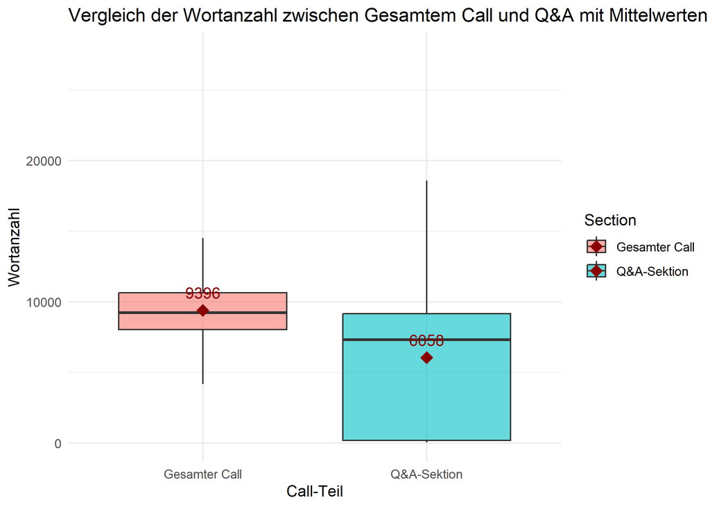

Der hier erstellte Boxplot zeigt auf der x-Achse den gesamten Call und die Q&A-Sektion und auf der y-Achse die jeweilige Anzahl an Wörtern. Da die Q&A-Sektion ein Teil des gesamten Calls ist, kann diese nie mehr Wörter enthalten als der gesamte Call. Der rote Boxplot zeigt den gesamten Call und der türkisfarbene die Q&A-Sektion. Der rote Diamant in den beiden Plots stellt die durchschnittliche Anzahl an Wörtern dar - 9396 bei dem gesamten Call und davon entfallen im Schnitt 6058 auf die Q&A-Sektion. Man kann also sagen, dass knapp 2/3 des Calls aus der Q&A-Sektion bestehen.

## Themenkategorien und Sentiment-Scores

Nachdem Sie nun die Earnings Conference Calls in R eingelesen und einen ersten Eindruck von deren Inhalt erhalten haben sollten Sie diese mit einem LLM (konkret mit Google Gemini) analysieren. Dafür sollten Sie einen Zero-Shot Prompt erstellen und mit Hilfe dieses Prompts die Aussage der Q&A Sektionen der Earnings Conference Calls analysieren.

9. Entwickeln Sie einen Zero-Shot Prompt für ein Large Language Model (LLM), der Earnings Conference Call Transcripts analysiert und strukturierte Sentiment-Bewertungen ausgibt. Bitte beachten Sie dabei folgende Punkte:

Zielkategorien:

- Unternehmensperformance (Finanzlage, Wachstumschancen, Unternehmensrisiken)
- Marktumfeld (Branche, Wettbewerb, externe Faktoren)

Output-Format:

- JSON-Struktur mit Sentiment-Scores von -1 (sehr negativ) bis +1 (sehr positiv)
- Keine zusätzlichen Erklärungen oder Markdown-Formatierung

Sie sollten in ihrem Prompt nach einem JSON Output verlangen (strukturiertes Format), welchen Sie mit dem Paket `jsonlite` gut in R verarbeiten können.

*Hinweis 1:* Im Anhang ist eine Erklärung für die Unterschiede zwischen einem Zero-Shot Prompt, einem One-Shot Prompt und einem Few-Shot Prompt

*Hinweis 2:* Wir haben Ihnen ein [Tutorial zusammengestellt](https://projektkurs-data-science-ulm2425.netlify.app/tutorials/zero-prompting), welches das Prompting an einem Beispiel zeigt.

Analysiere das folgende Transcript eines Earnings Conference Calls. Bewerte den allgemeinen Ton und die Aussagen in Bezug auf die folgenden Zielkategorien:

Unternehmensperformance: - Finanzlage - Wachstumschancen - Unternehmensrisiken

Marktumfeld: - Branche - Wettbewerb - Externe Faktoren

Gib als Ausgabe eine strukturierte JSON-Datei mit Sentiment-Scores zwischen -1 (sehr negativ) und +1 (sehr positiv) für jede der sechs Unterkategorien zurück. Verwende keine zusätzlichen Erklärungen, keine Kommentare und kein Markdown. Die Ausgabe soll ausschließlich die JSON-Struktur enthalten, wie im folgenden Format:

json { “Unternehmensperformance”: { “Finanzlage”: 0.5, “Wachstumschancen”: 0.2, “Unternehmensrisiken”: -0.3 }, “Marktumfeld”: { “Branche”: 0.1, “Wettbewerb”: -0.1, “Externe Faktoren”: 0.0 } } Verwende diese Struktur exakt und gib nur die JSON-Ausgabe zurück.

10. Im nächsten Schritt sollten Sie sich in das Paket [`ellmer`](https://ellmer.tidyverse.org/) einarbeiten. Durch `ellmer` erhalten Sie Zugriff auf alle gängigen LLMs mittels R über einen API Zugang. Wir haben ihnen für dieses Projekt ein Google Konto pro Gruppe erstellt und den API Schlüssel für jede Gruppe in das dazugehörige Repo (Readme) gepushed.
- Lesen Sie sich in das [`ellmer`](https://ellmer.tidyverse.org/) Paket ein und wie Sie den API Schlüssel für Google Gemini in ihrer .Renviron Datei hinterlegen können
- Untersuchen Sie die unterschiedlichen Modelle, die Google zur Verfügung stellt und deren Ratelimits: https://ai.google.dev/gemini-api/docs/models?hl=de

Bitte beantworten Sie folgende Fragen:

- Was sind die Vorteile/Nachteile der einzelnen Google Modelle?
- Welches (kostenlose) Modell würden Sie für ihre aktuellen Analysen bevorzugt einsetzen? Begründen Sie!
- Welche Möglichkeiten haben Sie, nicht in die Ratelimits zu kommen?
- In `ellmer` können Sie mittels dem [`params()`](https://www.tidyverse.org/blog/2025/05/ellmer-0-2-0/#parameters) Parameter auch die Temperatur ihres Modells einstellen. Was ist mit der Temperatur gemeint und was sind die Vorteile/Nachteile einer niedrigen Temperatur?

**Was sind die Vorteile/Nachteile der einzelnen Google Modelle?**

Google bietet drei zentrale Modelle zur Nutzung an, nämlich Gemini 1.5 Pro, Gemini 1.5 Flash, sowie Gemini 1.5 Flash-Lite. Jede von diesen Modellen hat spezielle Vorteile, aber auch Nachteile in der Nutzung. Gemini 1.5 Pro hat unter allen Modellen die beste Antwortqualität und ein starkes Kontextverständnis. Das Modell bietet sich daher speziell für komplexere und verschachteltere Prompts an. Mit den Eingabelimit von 1.048.576 Tokens ist es wunderbar geeignet für große Datenmengen und lange Codeanalysen. Außerdem ist das “Gedächtnis” der Pro-Version sehr gut und Kontextlogik kann über längere Sessions gespeichert werden. Pro ist zusammengefasst die beste Version für den wissenschaftlichen Textvergleich sowie die tiefe chatbasierte Anwendung. Ein großer Nachteil der Pro-Version ist die langsame Antwortzeit. Zudem hat Pro im Vergleich zu den anderen Modellen einen niedrigeren RPM (“Requests per Minute”) von 5. Das bedeutet, dass Gemini Pro nur fünf Antworten pro Minute gegen kann. Zudem hat es mit 100 Tokens pro Minute die geringste Anzahl aller Modelle. Je nach Preisstufe erhöht sich das Können, im Vergleich zu den anderen Versionen bleibt es aber im Rückstand. Das Flash-Modell ist zwischen den drei Modellen der Allrounder. Es ist ein guter Kompromiss zwischen Geschwindigkeit und Genauigkeit. Es ist am Besten für Aufgaben geeinget, die niedrige Latenz und hohes Volumen erfordern. Es hat mit 10 einen höheren RPM als die Pro Version, aber immer noch einen niedrigeren als die Flash Lite Version. Bei den 250 RPDs gilt dasselbe. Es ist die beste Version für mittelgroße Aufgaben. Nachteil ist, dass die normale Flash Version in ihren Eigenschaften so gut wie immer von den anderen beiden outperformed wird. Bei der Datenverarbeitung kann es mit der Pro Version nicht mithalten, während es in der Geschwindigkeit der Lite Version weichen muss - trotzdessen ist sie überall grundsolide, was das Allrounder-Statement unterstreicht. Die Flash Light Version ist vor allem für kleine Projekte, die schnell erledigt werden müssen gut geeignet. Es hat die kürzeste Latenz aller Modelle. Es hat das höchste RPM (mit 15), sowie das höchste RPD (1000). So ist es auch für einfache langwierige Prozesse gut geeignet. Preistechnisch sind die kostenpflichtigen Versionen hier auch am Billigsten. Die Flash Light Version hat jedoch Probleme mit größeren Datenmengen und hat auch die schlechteste Antwortqualität. Es hat niedrigeren Token Input, sowie Output (1.000.000 bzw. 64.000) als die anderen Versionen. Sollten also schwierige Prompts bearbeitet werden müssen, ist dieses Modell eher nicht zu empfehlen.

**Welches (kostenlose) Modell würden Sie für ihre aktuellen Analysen bevorzugt einsetzen? Begründen Sie!**

Jedes Modell hat ihre Vorzüge, allerdings auch ihre Nachteile. Unser Projektkurs bedarf komplexer Datenverarbeitung, was primär die Pro-Version bevorzugen würde. Geschwindigkeit ist dabei nicht entscheidend, was für uns persönlich die Flash Lite Version bereits ausschließt, da diese in der Datenverarbeitung eindeutige Schwächen aufweist. Zwischen den verbleibenden Modellen entscheidet das Prinzip der Abwägung. Auch wenn das Verarbeiten von komplexen Daten zunächst am Wichtigsten erscheint, ist hervorzuheben, dass mit der Pro Version früher das Ratelimit erreicht ist als mit der Flash Version. So kann vor allem an einem langen Arbeitstag die Grenze schnell erreicht sein. Dies ist auch bei der jetztigen Projektarbeit nicht anders. Lieber ein sehr solides Modell, als ein Modell, das zwar kurzfristig super Leistungen erbringt, aber nach kurzer Zeit nicht mehr zu Verwenden ist. Deshalb würden wir uns im Sinne dieses Projektkurses für das “Gemini Flash”-Modell entscheiden.

**Welche Möglichkeiten haben Sie, nicht in die Ratelimits zu kommen?**

Es gibt mehrere Möglichkeiten, das frühe Erreichen der Ratelimits zu verhindern oder zumindest zu verzögern. Eine Möglichkeit wäre es, die Prompts zu kürzen um weniger Tokens pro Anfrage zu verbrauchen. Eine klare, präzise Aufgabenstellung führt zu kurzeren und fokussierteren Antworten der AI. Außerdem sollten nur relevante Kontexte mitgesendet werden. Es sind keine Wiederholungen ganzer Chatverläufe oder Datenblöcke notwendig. Auch eine zeitliche Staffelung der Arbeitszeit wäre sinnvoll, um RPM-Limits zu umgehen. Auch die Verteilung der Aufgaben auf mehrere Personen verringert die Anfragen des Einzelnen. Es wäre ebenso denkbar, für einfachere Aufgaben in den Flash Lite Modus zu wechseln, da dort das Limit deutlich höher ist. Im letzten Case bleibt dann noch die Möglichkeit mithilfe eines kostenpflichtigen Abos auf eine verbesserte Version upzugraden und dadurch höhere Ratelimits zu bekommen.

**Was ist mit der Temperatur gemeint und was sind die Vorteile/Nachteile einer niedrigen Temperatur?**

Die Temperatur in einem Sprachmodell wie Gemini steuert, wie zufällig bzw. kreativ die generierten Antworten sind. In ellmer lässt sich dieser Wert mit der Funktion params() anpassen. Eine niedrige Temperatur (zum Beispiel 0.1 oder 0.2) führt dazu, dass das Modell bevorzugt die wahrscheinlichsten Antworten wählt. Die Resultate sind dadurch sehr konsistent und wiederholbar, was insbesondere für analytische oder technische Aufgaben von Vorteil ist. So lassen sich etwa faktentreue Erklärungen, zuverlässige Klassifizierungen oder reproduzierbare Ergebnisse erzielen, ein entscheidender Pluspunkt bei Anwendungen wie Datenanalyse, Codegenerierung oder strukturierter Textverarbeitung in R. Allerdings hat eine niedrige Temperatur auch klare Nachteile: Die Antworten wirken oft wenig kreativ oder starr, und bei mehrdeutigen Aufgaben bleibt das Modell strikt bei einer einzigen Deutungsmöglichkeit. Es zeigt also keine Vielfalt in den Formulierungen oder Ideen, was bei kreativen Anwendungsfällen wie Brainstorming, Textproduktion oder offenen Interpretationen hinderlich sein kann. Insgesamt eignet sich eine niedrige Temperatur hervorragend für präzise, kontrollierte und faktenorientierte Anwendungen, während für mehr kreative oder explorative Aufgaben eine höhere Temperatureinstellung sinnvoller ist.

11. Nutzen Sie ihren in Aufgabe 9 erstellten Prompt mit dem `ellmer` Paket und ihrem Google API-Key um alle 431 Earnings Conference Call Transkripte zu analysieren. Nutzen Sie für ihre Analyse das Modell Google Gemini 2.0-flash oder Google Gemini 2.5-flash.

Speichern Sie die Ergebnisse ihrer Analyse in einem strukturierten Tibble ab. Anschließend sollten Sie den Datensatz auch unter `data/sentiment.Rds` abspeichern.

Stellen Sie ihre Ergebnisse in einer Tabelle dar und beschreiben diese kurz:

- Wie ist der Mittelwert, Standardabweichung und Median der Einschätzung bezüglich Unternehmensperformance und Marktumfeld in ihren Earnings Conference Calls?

*Hinweis 1:* Achten Sie darauf nicht bei jedem Knitten die Analyse neu zu starten, sondern setzen Sie den Chunk dieser Aufgabe auf `eval = FALSE` und lassen Sie die Analyse nur einmal durchlaufen und speichern Sie die Ergebnisse ab (und laden diese später um damit weiterarbeiten zu können)

*Hinweis 2:* Achten Sie auf ihre Ratelimits und beanspruchen Sie den API Zugriff nicht zu stark, z.B. durch den Einbau von “sleep”-Zeiten in ihrem Code

Deskriptive Statistiken: Unternehmensperformance & Marktumfeld

| Kategorie | Mittelwert | Standardabweichung | Median |
| --- | --- | --- | --- |
| Unternehmensperformance | 0.49 | 0.21 | 0.50 |
| Marktumfeld | 0.39 | 0.27 | 0.43 |

Die folgende Tabelle zeigt die deskriptiven Statistiken – Mittelwert, Standardabweichung und Median – für zwei übergeordnete Sentiment-Dimensionen, die aus den Q&A-Sektionen von Earnings Conference Calls extrahiert wurden. Die Skala reicht von –1 (sehr negativ) bis +1 (sehr positiv).

Unternehmensperformance: Mit einem Mittelwert von 0.49, einer Standardabweichung von 0.21 und einem Median von 0.50 wird die Unternehmensperformance insgesamt als leicht positiv eingeschätzt. Dieser Wert spiegelt die aggregierte Wahrnehmung interner Faktoren wie finanzielle Stabilität, Wachstumsaussichten und Unternehmensrisiken wider. Die vergleichsweise geringe Streuung deutet auf eine relativ konsistente Einschätzung unter den analysierten Unternehmen hin.

Marktumfeld: Das Marktumfeld wird mit einem Mittelwert von 0.39, einer höheren Standardabweichung von 0.27 und einem Median von 0.43 ebenfalls positiv, jedoch etwas verhaltener bewertet. Diese Kennzahlen fassen die externe Wahrnehmung hinsichtlich Branche, Wettbewerb und makroökonomischer Faktoren zusammen. Die größere Streuung zeigt, dass die Einschätzungen hier stärker auseinandergehen, was auf Unsicherheiten oder heterogene Marktbedingungen hindeuten kann.

Fazit: Insgesamt zeigt sich, dass die Stimmung hinsichtlich der unternehmensinternen Lage tendenziell positiver ausfällt als im Hinblick auf das externe Marktumfeld. Während Unternehmen ihre eigene Situation überwiegend optimistisch bewerten, bleibt der Blick nach außen von mehr Unsicherheit geprägt.

Sie haben in der vorherigen Aufgabe die Stimmung bezüglich der Kategorien Unternehmensperformance und Marktperformance in den Earnings Conference Calls bestimmt. Eine Frage wäre, ob sich diese Stimmung über die Zeit hinweg verändert hat. In der folgenden Aufgabe sollen Sie sich die durchschnittliche Stimmung in diesen zwei Kategorien für die einzelnen Jahre in ihrem Datensatz näher anschauen.

12. Erstellen Sie eine geeignete Grafik um die Stimmung *aller Earnings Conference Calls eines Jahres* zu visualisieren. Tragen Sie separat die Stimmung bezüglich Unternehmensperformance und Marktumfeld ab.

Beschreiben Sie ihre Grafik.

Interpretieren Sie diese Grafik, insbesondere im Hinblick auf die gesamtwirtschaftlichen Ereignisse der letzten fünf Jahre. Hätten Sie die Ergebnisse in dieser Art erwartet?

*Hinweis:* Sie sollten sich hier eine sinnvolle Grafik überlegen, welche die Stimmungslage über die Zeit gut darstellt.

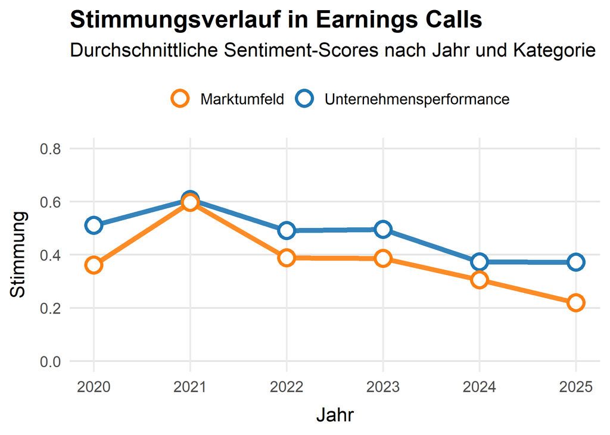

# Eventstudie

Um zu evaluieren, ob die Earnings Conference Calls tatsächlich einen Einfluss auf die Aktienkurse der einzelnen Unternehmen hatten können Sie eine sogenannte Eventstudie durchführen, welche Sie bereits in Aufgabe 1 kennen gelernt haben. Bei einer Eventstudie betrachten Sie nur die Zeit (bei uns die Tage) unmittelbar vor oder nach einem Event. In diesem Projekt ist ein Event ein Earnings Conference Call des jeweiligen Unternehmens. Sie sollen in diesem Projekt herausfinden, wie sich über alle Unternehmen hinweg die Earnings Conference Calls auf die Aktienrenditen auswirken.

13. Verbinden Sie den Datensatz über die *Stimmung der Earnings Conference Calls (sentiment.Rds)* zu den einzelnen Unternehmen mit den *abnormalen Renditen* und speichern diesen Datensatz als `gesamtdatensatz` in R ab. Sie können das RIC-Kürzel und Datum für den Join verwenden. Sollte der Earnings Conference Call an keinem Handelstag stattgefunden haben, so joinen Sie bitte mit dem darauffolgenden Handelstag.
- Für die Tage an denen ein Earnings Conference Call stattgefunden hat sollten Sie eine Variable `event` generieren, welche an dem Tag des Calls gleich 0 ist.
- Für die Tage vor dem Earnings Conference Call (Event) sollte die Variable `event` rückwärts zählen (bis zu -5). Für alle Tage nach dem Event sollte die Variable `event` fortgeführt werden (bis +5).
- Erstellen Sie eine Variable `ar_505`, welche die *abnormalen Rendite* von Tag -5 bis +5 **fortlaufend** aufsummiert
- Erstellen Sie eine Variable `car_101`, welche die kumulierte abnormale Rendite im Zeitraum -1 bis +1 um das Event beinhaltet
- Erstellen Sie weiterhin diese sechs neuen Variablen:
  - `negativ_firm` = Wenn die Unternehmensperformance als negativ eingeschätzt wird
  - `neutral_firm` = Wenn die Unternehmensperformance als neutral eingeschätzt wird
  - `positiv_firm` = Wenn die Unternehmensperformance als positiv eingeschätzt wird
  - `negativ_market` = Wenn die Marktperformance als negativ eingeschätzt wird
  - `neutral_market` = Wenn die Marktperformance als neutral eingeschätzt wird
  - `positiv_market` = Wenn die Marktperformance als positiv eingeschätzt wird
- Erstellen Sie Dummy Variablen, die 1 sind für ein bestimmtes Jahr. Bspw. eine Dummyvariable die 2020 heißt und für alle Beobachtungen im Jahr 2020 sollte diese Variable 1 sein, 0 sonst. Tun Sie dies für alle Jahre in ihrem Datensatz

*Hinweis:* Die Funktion cumsum() könnte für diese Aufgabe hilfreich sein

14. Erstellen Sie je ein Liniendiagramm für die von ihnen betrachteten Unternehmen: Eines für die Stimmung bezüglich der Unternehmensperformance und eines bezüglich der Marktperformance.

Sie sollten in ihren Grafiken die kumulierten Renditen im Zeitraum [-5,5] Tage um einen Earnings Conference Call darstellen. - Die Variable “Event” sollte die Tage vor und nach dem Earnings Conference Call enthalten ([-5,5]) und auf der x-Achse dargestellt werden - Die Variable `ar_505` sollte die durchschnittliche kumulierte abnormale Rendite für den jeweiligen Tag auf der y-Achse abtragen (für alle Unternehmen in ihrem Datensatz) - In jeder Grafik sollten Sie eine extra Linie zeichnen für Earnings Conference Calls mit einer positiven/negativen und neutralen Stimmung und deren Einfluss auf den Aktienmarkt

Beschreiben und interpretieren Sie ihre Grafik. Gehen Sie hierbei insbesondere darauf ein, welche Erwartungen Sie auf der Basis ihrer Lektüre aus Aufgabe 1 hatten und in wie weit diese Erwartungen sich erfüllt haben.

*Hinweis:* In diesen Grafiken stellen Sie nicht jedes Event (d.h. die Auswirkungen eines jeden Earnings Conference Calls) einzeln dar, sondern gesamt für alle Earnings Conference Calls.

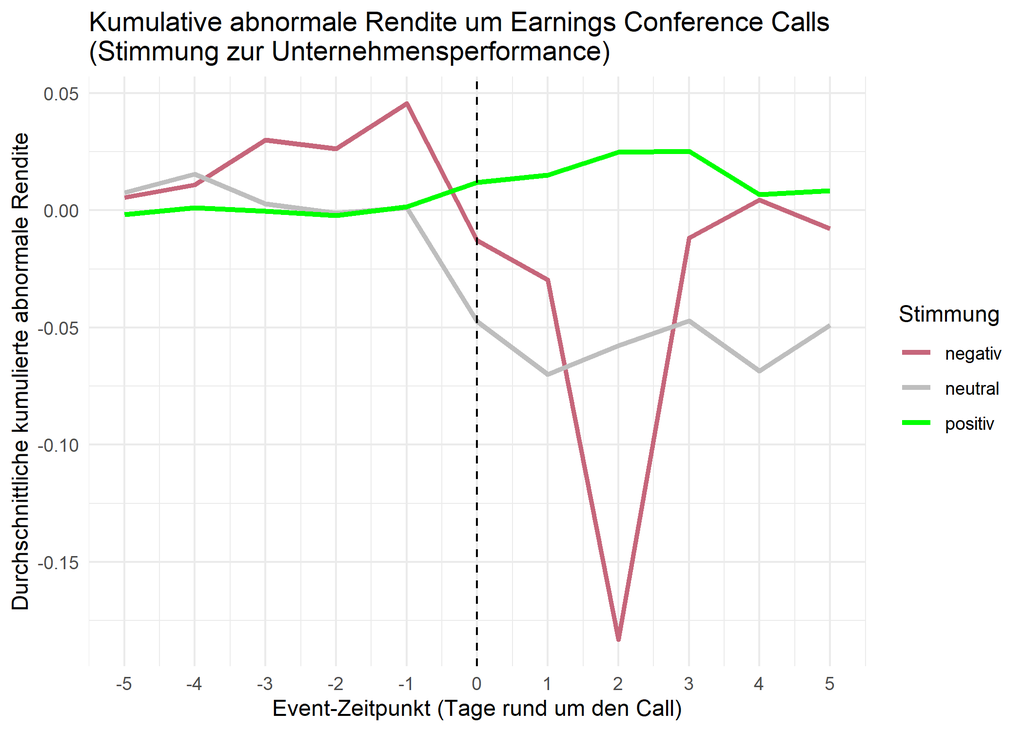

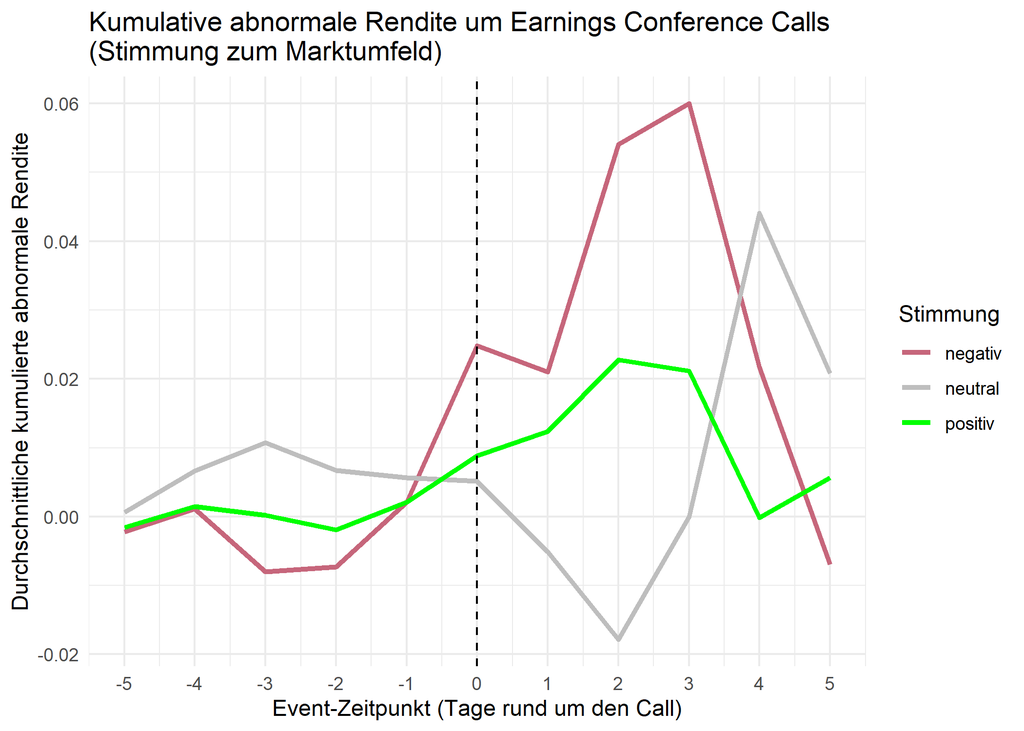

**Beschreibung und Interpretation**

Zur Analyse der Wirkung von Earnings Conference Calls (ECCs) auf Aktienrenditen wurden zwei Liniendiagramme erstellt, die die durchschnittliche kumulierte abnormale Rendite (AR) im Zeitraum von fünf Tagen vor bis fünf Tage nach dem jeweiligen Call darstellen. Dabei wurde zwischen drei Stimmungslagen unterschieden – positiv, neutral und negativ – jeweils einmal bezogen auf die Unternehmensperformance und einmal auf das allgemeine Marktumfeld.

In der ersten Grafik, die die Stimmung zur Unternehmensperformance abbildet, zeigen sich deutliche Unterschiede in den Renditeverläufen in Abhängigkeit von der jeweiligen Stimmungslage. Bei negativ gestimmten Calls ist ein starker Rückgang der kumulierten abnormalen Rendite unmittelbar nach dem Ereigniszeitpunkt zu beobachten. Dies deutet darauf hin, dass Anleger negative Aussagen über die Unternehmensperformance schnell und deutlich in Form fallender Aktienkurse einpreisen. Umgekehrt zeigt sich bei positiv gestimmten Calls eine stabile bis leicht positive Kursentwicklung, jedoch ohne starke Ausschläge nach oben. Auffällig ist die Asymmetrie der Marktreaktionen: Während negative Aussagen zu deutlich negativen Renditen führen, scheinen positive Aussagen nur eine begrenzte Wirkung zu entfalten. Dies entspricht gängigen Erkenntnissen aus der Kapitalmarktforschung, wonach negative Nachrichten häufig stärkere Kursreaktionen hervorrufen als positive („bad news effect“).

# Regressionen

Sie haben bisher den Einfluss der Earnings Conference Calls auf die Aktienrendite der größten europäischen Unternehmen im Technologie-Sektor visuell betrachtet. Im letzten Abschnitt dieser Projektarbeit analysieren Sie ihre Daten mittels linearer Regressionen.

15. In dieser Aufgabe sollten Sie zwei Regressionen erstellen:

Regressieren Sie die kumulierten abnormalen Renditen um das Event `car_101` auf die Dummyvariablen

- `negativ_firm` und `negativ_market` in der ersten Regression und
- `positiv_firm` und `positiv_market` in der zweiten Regression.

Diese Dummyvariablen geben die Stimmung in den Earnings-Conference Calls wieder.

Beschreibung und interpretieren Sie ihre Regressionsergebnisse und gehen Sie dabei auch auf folgende Fragen ein:

- Was ist die Vergleichsgruppe in den beiden Regressionen?
- Was sind die Voraussetzungen für eine kausale Interpretation der Koeffizienten. Sind diese ihrer Meinung nach gegeben?

|  | Negative Stimmung | Positive Stimmung |
| --- | --- | --- |
| Unternehmensspezifisch negativ | -0.047 |  |
|  | (0.043) |  |
| Marktbezogen negativ | 0.029 |  |
|  | (0.026) |  |
| Unternehmensspezifisch positiv |  | 0.050* |
|  |  | (0.019) |
| Marktbezogen positiv |  | -0.012 |
|  |  | (0.012) |
| Num.Obs. | 392 | 392 |
| R2 | 0.005 | 0.017 |
| Std.Errors | IID | IID |

+ p < 0.1, * p < 0.05, ** p < 0.01, *** p < 0.001

Im abschließenden Teil der Analyse wurde untersucht, inwiefern die Stimmung in den Earnings Conference Calls (ECCs) einen Einfluss auf die kumulierten abnormalen Renditen (CARs) der betrachteten Unternehmen hat. Zu diesem Zweck wurden zwei separate lineare Regressionen geschätzt, in denen die abhängige Variable car_101 – also die CARs im Zeitraum um das Ereignis – auf Stimmungs-Dummyvariablen regressiert wurde. Diese Dummyvariablen erfassen, ob die jeweilige Stimmung im Call entweder negativ (negativ_firm, negativ_market) oder positiv (positiv_firm, positiv_market) war.

In der ersten Regression wurde der Einfluss negativer Stimmung untersucht. Die geschätzten Koeffizienten für negativ_firm (-0,047) und negativ_market (+0,029) sind dabei statistisch nicht signifikant, was darauf hinweist, dass sich eine negative Tonalität in den firmenspezifischen oder marktbezogenen Aussagen im Durchschnitt nicht eindeutig auf die CARs auswirkt. Lediglich der Intercept ist signifikant positiv (+0,012, p < 0,05), was bedeutet, dass Unternehmen im Fall einer neutralen Stimmung im Durchschnitt leicht positive CARs aufwiesen. Insgesamt erklärt das Modell jedoch nur einen sehr geringen Anteil der Varianz (R² = 0,005).

In der zweiten Regression wurde der Einfluss positiver Stimmung analysiert. Hier zeigt sich ein signifikanter positiver Effekt für positiv_firm (+0,050, p < 0,05), was darauf hinweist, dass eine optimistische Tonalität in firmenspezifischen Aussagen mit einer durchschnittlich um fünf Prozentpunkte höheren CAR einhergeht. Die Variable positiv_market ist hingegen nicht signifikant, sodass keine systematische Wirkung marktbezogener positiver Aussagen festgestellt werden kann. Der Intercept ist negativ (-0,025), jedoch statistisch nicht signifikant. Das Modell erklärt etwas mehr Varianz als die erste Regression (R² = 0,017), bleibt aber insgesamt erklärungsschwach.

Die Vergleichsgruppe in beiden Regressionen besteht jeweils aus den Beobachtungen mit neutraler Stimmung, also jenen Calls, in denen keine der verwendeten Dummyvariablen den Wert 1 aufweist. Die geschätzten Effekte der Stimmungsvariablen sind somit als Abweichungen von dieser neutralen Basislinie zu interpretieren.

Für eine kausale Interpretation der Regressionskoeffizienten müssen bestimmte Voraussetzungen erfüllt sein, etwa die Exogenität der Regressoren, das Fehlen von unbeobachteten Störgrößen (Omitted Variable Bias), sowie die Abwesenheit von Selektionseffekten oder Endogenität. Diese Bedingungen sind in der vorliegenden Analyse nur eingeschränkt erfüllt. Insbesondere ist nicht ausgeschlossen, dass die Stimmung im Call strategisch gewählt wird oder selbst durch antizipierte Marktreaktionen beeinflusst ist. Zudem könnten relevante Kontrollvariablen, wie etwa die tatsächlichen finanziellen Kennzahlen oder makroökonomische Entwicklungen, fehlen. Insofern sollte die Interpretation der Ergebnisse vor allem als deskriptiv und hypothesengenerierend verstanden werden, nicht jedoch als Nachweis eines kausalen Zusammenhangs.

16. In ihrer deskriptiven Analyse haben Sie bereits gesehen, dass die Unternehmen, die Sie in diesem Projekt betrachten, alle unterschiedlich groß sind. Weiterhin haben Sie gesehen, dass es ein unterschiedliches Stimmungsbild in den Calls über die einzelnen Jahre hinweg gibt. Dafür möchten Sie in ihren Regressionen nun kontrollieren.
    1. Regressieren Sie die `car_101` auf die Variablen *negativ_firm* und *negativ_market* und kontrollieren Sie auf die Größe des jeweiligen Unternehmens, indem Sie die Variable *Total_Assets* in ihre Regression aufnehmen
    2. Fügen Sie in einer zweiten Analyse zusätzlich zu den Variablen aus der 1. Regression auch noch Dummyvariablen für die Jahre in dem das Event stattgefunden hat ihrer Regression hinzu.
    3. Führen Sie die Regressionen aus 1. und 2. auch für die Variablen *positiv_firm* und *positiv_market* anstatt *negativ_firm* und *negativ_market* durch, sodass Sie am Ende 4 Regressionen haben

Beschreiben und interpretieren Sie ihre Ergebnisse im Hinblick auf die Größe der Koeffizienten und deren Signifikanz. Gehen Sie insbesondere auf folgende Fragen ein:

- Warum sollte ihre Regression nicht fünf Dummyvariablen, je eine für jedes Jahr, sondern nur vier beinhalten?
- Verändert sich durch die Dummyvariablen der Koeffizient von *negativ_firm* und *negativ_market* bzw. *positiv_firm* und *positiv_market*?
- Hätten Sie eine Veränderung des Koeffizienten von *negativ_firm*, *negativ_market*, *positiv_firm* oder *positiv_market* erwartet? Begründen Sie ihre Antwort mit ihren deskriptiven Analysen.

|  | Negativ (nur Größe) | Negativ (Größe + Jahr) | Positiv (nur Größe) | Positiv (Größe + Jahr) |
| --- | --- | --- | --- | --- |
| Unternehmensspezifisch negativ | -0.010 | -0.006 |  |  |
|  | (0.047) | (0.047) |  |  |
| Marktbezogen negativ | -0.019 | -0.016 |  |  |
|  | (0.029) | (0.029) |  |  |
| Unternehmensspezifisch positiv |  |  | 0.040+ | 0.037+ |
|  |  |  | (0.021) | (0.021) |
| Marktbezogen positiv |  |  | 0.005 | 0.006 |
|  |  |  | (0.013) | (0.013) |
| Unternehmensgröße (log Total Assets) | -0.000 | -0.000 | -0.000 | -0.000 |
|  | (0.000) | (0.000) | (0.000) | (0.000) |
| Jahr: 2021 |  | -0.005 |  | -0.007 |
|  |  | (0.015) |  | (0.015) |
| Jahr: 2022 |  | 0.004 |  | 0.003 |
|  |  | (0.015) |  | (0.015) |
| Jahr: 2023 |  | 0.004 |  | 0.008 |
|  |  | (0.015) |  | (0.015) |
| Jahr: 2024 |  | -0.021 |  | -0.017 |
|  |  | (0.015) |  | (0.015) |
| Jahr: 2025 |  | 0.053 |  | 0.052 |
|  |  | (0.091) |  | (0.090) |
| Num.Obs. | 358 | 358 | 358 | 358 |
| R2 | 0.003 | 0.015 | 0.016 | 0.027 |
| Std.Errors | IID | IID | IID | IID |

+ p < 0.1, * p < 0.05, ** p < 0.01, *** p < 0.001

**Interpretation Aufgabe 16: Einfluss von Unternehmensgröße und Jahres-Dummies auf die Wirkung von Stimmungsindikatoren**

In Aufgabe 16 wurde der Einfluss der Earnings-Call-Stimmung auf die kumulierten abnormalen Renditen (car_101) mithilfe von vier linearen Regressionsmodellen untersucht. Zwei Modelle enthalten ausschließlich die Kontrollvariable für Unternehmensgröße (value_ta), die anderen beiden zusätzlich Jahres-Dummyvariablen (factor(Jahr)). Die erklärenden Hauptvariablen sind in den ersten beiden Regressionsmodellen negativ_firm und negativ_market sowie in den letzten beiden positiv_firm und positiv_market. Die Ergebnisse werden im Folgenden detailliert analysiert.

*Regression 1: Negatives Sentiment + Unternehmensgröße*

Modell: car_101 ~ negativ_firm + negativ_market + value_ta

In diesem Modell wird untersucht, ob negative Stimmung in ECCs einen Einfluss auf die kumulierten abnormalen Renditen hat, kontrolliert für die Unternehmensgröße. Die geschätzten Koeffizienten für negativ_firm (–0.010) und negativ_market (–0.019) sind nicht signifikant, was darauf hinweist, dass negative Aussagen – weder auf Firmen- noch auf Marktebene – die CARs in dieser Spezifikation nicht systematisch beeinflussen. Die Unternehmensgröße (value_ta) hat ebenfalls keinen signifikanten Einfluss. Das Modell erklärt nur sehr wenig Varianz (R² ≈ 0.003).

Interpretation: Negative Tonalität scheint allein, ohne Kontrolle für zeitliche Effekte, keinen erkennbaren Einfluss auf die kurzfristigen abnormalen Renditen zu haben.

*Regression 2: Negatives Sentiment + Unternehmensgröße + Jahres-Dummies*

Modell: car_101 ~ negativ_firm + negativ_market + value_ta + factor(Jahr)

Hier wird zusätzlich für Unterschiede zwischen den Jahren kontrolliert. Auch in diesem Modell bleiben die zentralen Variablen negativ_firm (–0.006) und negativ_market (–0.016) nicht signifikant. Die Jahr-Dummies selbst sind ebenfalls nicht signifikant, was auf eine stabile Beziehung über die Jahre hinweg schließen lässt. Der Erklärungsgehalt des Modells steigt nur geringfügig (R² ≈ 0.015).

Interpretation: Auch unter Kontrolle von Jahresunterschieden zeigt sich kein signifikanter Effekt negativer Stimmung auf die CARs. Die Ergebnisse sind robust und bestätigen, dass negative Aussagen keine messbare kurzfristige Kursreaktion auslösen.

*Regression 3: Positives Sentiment + Unternehmensgröße*

Modell: car_101 ~ positiv_firm + positiv_market + value_ta

In dieser Regression wird geprüft, ob positive Stimmung die CARs beeinflusst. Der Koeffizient von positiv_firm ist mit 0.040 signifikant auf dem 10%-Niveau, was auf einen leichten positiven Einfluss hinweist. positiv_market bleibt insignifikant, ebenso wie value_ta. Das Modell hat einen leicht höheren Erklärungsgehalt (R² ≈ 0.016).

Interpretation: Positive firmenspezifische Aussagen führen tendenziell zu leicht höheren abnormalen Renditen. Dies spricht dafür, dass der Markt optimistische Aussagen des Managements honoriert, während Marktstimmung allein keine Rolle spielt.

*Regression 4: Positives Sentiment + Unternehmensgröße + Jahres-Dummies*

Modell: car_101 ~ positiv_firm + positiv_market + value_ta + factor(Jahr)

Mit Kontrolle für Jahrgangseffekte bleibt der Effekt von positiv_firm stabil bei 0.037 und signifikant auf dem 10%-Niveau. Auch hier bleibt positiv_market insignifikant. Die Jahresdummies sind ebenfalls nicht signifikant, was auf zeitlich robuste Effekte hindeutet. Das Modell erklärt insgesamt etwas mehr Varianz (R² ≈ 0.027).

Interpretation: Der positive Effekt firmenspezifischer Stimmung bleibt auch unter Kontrolle von Jahresdummies bestehen und robust. Das deutet darauf hin, dass unabhängig vom Jahr positive Aussagen eines Unternehmens einen leicht positiven Effekt auf die Aktienrendite haben.

**Vergleich und Meta-Analyse**

Warum nur vier Jahres-Dummies?: In der Regressionsanalyse mit kategorialen Variablen wie Jahren darf nie für alle Kategorien ein Dummy gleichzeitig verwendet werden – dies würde zu perfekter Multikollinearität führen (sog. „Dummy-Variable Trap“). Eine Referenzkategorie (z.B. Jahr 2020) muss ausgelassen werden, damit die Modellparameter eindeutig bestimmbar sind. Die Effekte der Dummies interpretieren sich dann relativ zu diesem Referenzjahr.

Veränderung der Koeffizienten durch die Dummyvariablen: Nein, die zentralen Koeffizienten verändern sich nur minimal durch die Hinzunahme der Jahresdummies: negativ_firm: von –0.010 → –0.006 negativ_market: von –0.019 → –0.016 positiv_firm: von 0.040 → 0.037 positiv_market: praktisch unverändert (0.005 → 0.006) Diese Veränderungen sind nicht substanziell, und die Signifikanzniveaus bleiben gleich. Das weist darauf hin, dass sich der Haupteffekt der Stimmungsvariablen nicht durch Jahrgangseffekte erklären lässt.

Erwartete Veränderungen?: Teilweise ja. In der deskriptiven Analyse deuteten sich jährliche Schwankungen im Sentiment sowie Unterschiede in der Reaktion auf Stimmungen an. Daher wäre es denkbar gewesen, dass sich der Einfluss z.B. von positiv_firm abschwächt oder verstärkt, wenn man für Jahrgänge kontrolliert. Die tatsächliche Stabilität der Koeffizienten zeigt jedoch, dass der Einfluss positiver firmenspezifischer Aussagen über die Jahre hinweg konsistent ist – unabhängig von etwaigen externen Marktentwicklungen oder Trends. Das spricht für robuste Effekte der firmenspezifischen positiven Stimmung.

17. Zum Abschluss sollten Sie dazu Stellung beziehen, in wie weit die Erkenntnisse aus diesem Projekt für eine Handelsstrategie genutzt werden könnten. Konkret sollten Sie erläutern ob es sinnvoll ist eine Unternehmensaktie bei einem negativem Sentiment im Earnings Conference Call automatisiert zu verkaufen.

Beziehen Sie sich in ihrer Argumentation insbesondere auf:

- Zeitliche Aspekte (Wann reagiert der Markt vs. wann liegt das Sentiment vor?)
- Methodische Limitationen Ihrer Event Study
- Unsicherheiten bei der LLM-Sentiment-Analyse

Begründen Sie jeden Kritikpunkt konkret mit Bezug auf Ihre Projektarbeit und schließen Sie mit einer realistischen Einschätzung ab: Wofür könnten Ihre Ergebnisse trotz dieser Limitationen in der Praxis dennoch wertvoll sein?

Zeitliche Verfügbarkeit des Sentiments im Vergleich zur Marktreaktion: Ein zentraler Aspekt, der gegen den unmittelbaren Einsatz einer automatisierten Handelsstrategie auf Basis von negativem Sentiment spricht, liegt in der zeitlichen Struktur von Information und Reaktion. Unsere Sentimentanalyse basiert auf der Auswertung von Transkripten der Earnings Conference Calls, wobei mithilfe eines Large Language Models (Google Gemini 2.5-flash) im Rahmen eines Zero-Shot-Prompts die Einschätzung der Aussagen extrahiert wurde. Diese Auswertung kann jedoch erst erfolgen, wenn der Call abgeschlossen und das Transkript verfügbar ist. Der Kapitalmarkt hingegen reagiert oftmals bereits während des Calls oder unmittelbar danach, wie die in den Aufgaben 4 und 5 berechneten abnormalen Renditen im engen Zeitfenster um das Event (-1 bis +1 Tage) gezeigt haben. Das bedeutet, dass das relevante Zeitfenster für eine profitable Handelsstrategie bereits abgelaufen ist, bevor das Sentiment vollständig analysiert und in einer automatisierten Entscheidung verarbeitet werden kann. Die Sentimentanalyse ist somit zeitlich nachgelagert und eignet sich daher nicht zur Echtzeitentscheidung im Rahmen eines algorithmischen Handelsansatzes.

Unsicherheiten in der LLM-basierten Sentimentanalyse: Ein weiterer Unsicherheitsfaktor betrifft die methodische Qualität der Sentimentanalyse selbst. Die Einschätzung des Sentiments erfolgte mithilfe eines Zero-Shot-Prompts, was zwar eine pragmatische und skalierbare Lösung darstellt, jedoch auch mit Risiken verbunden ist. Das Modell erhält keine Beispiele für positive oder negative Einstufungen und muss die Kategorisierung auf Basis des allgemeinen Sprachverständnisses vornehmen. Obwohl der Prompt sorgfältig gestaltet wurde und die JSON-Ausgabe konsistent war, können inhaltliche Verzerrungen auftreten. Besonders problematisch ist, dass das Modell Ironie, komplexe branchenspezifische Kontexte oder implizite Aussagen eventuell falsch interpretiert. Zudem basiert das Ergebnis auf der vollständigen Q&A-Sektion, unabhängig davon, ob alle Aussagen gleich gewichtet relevant sind. Auch konnten wir nicht sicherstellen, dass das Modell in allen Fällen stabil zwischen leicht negativem und neutralem Tonfall unterscheidet. Damit ist die Genauigkeit der Einstufung nicht mit der Präzision klassischer quantitativer Daten vergleichbar, was die Umsetzung in automatisierte Entscheidungen erschwert.

Realistische Einschätzung des praktischen Nutzens der Ergebnisse: Trotz dieser Limitationen können die Ergebnisse dieses Projekts in der Praxis durchaus eine unterstützende Rolle spielen. Zwar erscheint eine unmittelbare algorithmische Handelsstrategie, die automatisiert bei negativem Sentiment verkauft, aus zeitlichen und methodischen Gründen nicht sinnvoll. Jedoch liefert die Sentimentanalyse wichtige qualitative Zusatzinformationen, die in Research-Abteilungen, Portfoliomanagement oder Risikobewertungen eingesetzt werden könnten. Gerade die Ergebnisse der Regressionsanalysen zeigen, dass eine positive Firmeneinschätzung tendenziell mit positiven abnormalen Renditen verbunden ist, was Investoren als Signal im Rahmen strategischer Bewertungen nutzen könnten. Darüber hinaus könnten solche Analysen in Kombination mit anderen Marktsignalen genutzt werden, etwa zur Konstruktion robuster multifaktorieller Modelle. Für quantitative Analysten bietet das Projekt zudem einen Rahmen, um mit modernen NLP-Methoden systematisch qualitative Inhalte aus Finanzkommunikation zu strukturieren und in Modelle zu integrieren. Die Ergebnisse sind damit vor allem als exploratives und unterstützendes Werkzeug wertvoll, nicht aber als unmittelbare Entscheidungsgrundlage für vollautomatisierte Handelsstrategien.

# Zusatzaufgabe

In Aufgabe 6 berechnen Sie die *abnormalen Renditen* der einzelnen von ihnen betrachteten Unternehmen. Nun könnte es allerdings sein, dass es nicht ausreicht den Marktindex einfach von der Aktienrendite abzuziehen um für die erwartete Performance der Aktie zu kontrollieren. Potentiell wäre es besser für die durchschnittliche Performance der Aktie zu kontrollieren in der keine Events stattfinden.

Sie können eine solche durchschnittliche Performance schätzen. Dazu sollten Sie eine Schätzperiode *vor* dem Event definieren. Diese Periode sollen Sie auf 120 bis 10 Handelstage vor dem Event festlegen. Die durchschnittliche Rendite der Einzelaktie sollten Sie in dieser Periode auf die Marktrendite regressieren. Dieses Modell wird `Risk-adjusted returns model` in Huntington-Klein (2021) genannt:

$$\begin{equation}
\hat{Rendite}_{i,t} = \alpha + \beta Rendite_{m,t}
\end{equation}$$

Anschließend nutzen Sie die vorhergesagten Werte und ziehen diese in der Eventphase von der Rendite der Einzelaktie ab.

18. Erstellen Sie die kumulierten abnormalen Renditen im Zeitraum -5 bis +5 mit Hilfe ihres Risk-adjusted returns model neu (und nennen diese `mar_505`). Erstellen Sie die kumulierten abnormalen Renditen im Zeitraum -1 bis +1 um das Event mit Hilfe ihres Risk-adjusted returns model neu (und nennen die Variable `cmar_101`) und vergleichen die Werte in einer geeigneten Grafik mit den Ergebnissen aus dem market-adjusted returns model (`car_101`).
- Gibt es hier große Unterschiede?
- Warum gibt es diese Unterschiede, oder warum sehen Sie nur geringe Unterschiede?

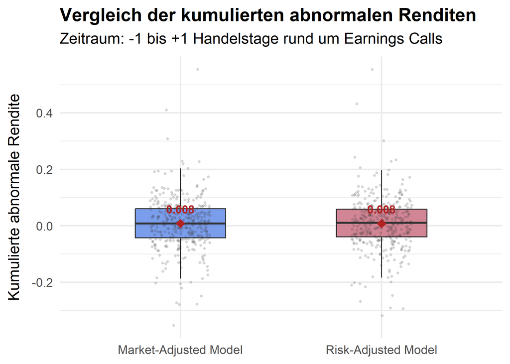

**Vergleich der kumulierten abnormalen Renditen: Market-Adjusted vs. Risk-Adjusted Modell**

Im Rahmen von Aufgabe 18 wurde die Berechnung der kumulierten abnormalen Renditen (CARs) im engen Event-Fenster von -1 bis +1 Handelstag um den Earnings Conference Call (ECC) mit zwei verschiedenen Methoden durchgeführt: dem einfachen Market-Adjusted Model (car_101) und dem differenzierteren Risk-Adjusted Returns Model (cmar_101). Ziel war es, die Aussagekraft beider Ansätze zu vergleichen und zu bewerten, ob die anspruchsvollere risikoadjustierte Methode zu relevanten Abweichungen in den Ergebnissen führt.

Die grafische Darstellung zeigt zwei Boxplots, die die Verteilung der kumulierten abnormalen Renditen nach beiden Modellen visualisieren. Die Mittelwerte der beiden Modelle sind identisch und betragen jeweils rund 0.008, was bedeutet, dass in beiden Fällen im Durchschnitt ein positiver Effekt im Event-Fenster zu beobachten ist. Auch die Streuung und die Form der Verteilung sind annähernd gleich. Das legt nahe, dass der gewählte methodische Zugang – ob einfach oder risikoadjustiert – in diesem konkreten Datensatz nur geringe Auswirkungen auf die zentralen Resultate hat.

**Gründe für geringe Unterschiede zwischen den Modellen**

Die beobachtete Übereinstimmung der Ergebnisse erklärt sich primär dadurch, dass sich die Marktrendite im gewählten Zeitraum offenbar als guter Proxy für die erwartete Rendite der Einzelaktien erwiesen hat. Da das Market-Adjusted Model lediglich die tatsächliche Marktrendite vom Unternehmensreturn subtrahiert, während das Risk-Adjusted Model zusätzlich alpha- und beta-spezifische Anpassungen vornimmt, wäre ein deutlicher Unterschied nur dann zu erwarten gewesen, wenn die Einzelaktien stark unterschiedliche systematische Marktsensitivitäten aufgewiesen hätten. Offensichtlich sind die geschätzten Betas in der Schätzperiode relativ homogen, sodass die Differenzierung durch das Risk-Adjusted Model in der aggregierten Betrachtung keine nennenswerte zusätzliche Information liefert.

Zudem ist der Untersuchungszeitraum um den Event herum sehr eng gewählt (nur drei Handelstage), was die Wahrscheinlichkeit verringert, dass sich größere systematische Effekte über längere Halteperioden hinweg entfalten können. In einem weiteren Zeitfenster könnten sich Unterschiede stärker bemerkbar machen.

**Implikationen für die Anwendung**

Aus praktischer Perspektive bedeutet dieses Ergebnis, dass das einfache Market-Adjusted Model – trotz seiner methodischen Simplizität – in vielen Fällen ausreichend ist, um die Richtung und ungefähre Größe abnormaler Renditen zu erfassen. Das kann insbesondere in Anwendungen von Vorteil sein, in denen schnelle Berechnungen oder limitierte Datenverfügbarkeit eine Rolle spielen. Dennoch bleibt das Risk-Adjusted Model theoretisch überlegen, insbesondere wenn die Marktsensitivität zwischen Unternehmen stark variiert oder wenn die Schätzperiode Störereignisse enthält. In diesen Fällen könnte eine individuelle Schätzung von alpha und beta dazu beitragen, Verzerrungen zu vermeiden.

Zusammenfassend lässt sich sagen: Im vorliegenden Projekt lieferten beide Ansätze nahezu identische Resultate, was auf eine robuste methodische Anlage hinweist. Der Nutzen des Risk-Adjusted Models zeigt sich somit eher in seiner konzeptionellen Strenge als in unmittelbar verbesserten Ergebnissen in diesem konkreten Anwendungsfall.

19. Erstellen Sie die Grafik von Aufgabe 14 neu.

Beschreiben und interpretieren Sie ihre Grafik. Gehen Sie auch auf folgende Fragen ein:

- Könnte es zu Problemen führen, wenn in der Schätzperiode vor dem Event ein weiterer Earnings-Conference Call enthalten ist?
  - Warum könnte dies ein Problem sein, oder warum nicht?

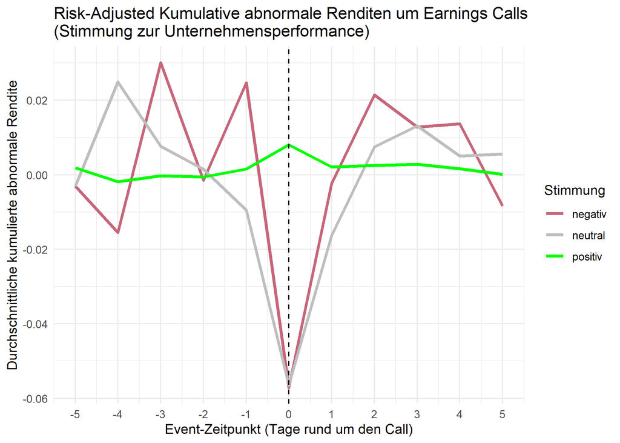

**Interpretation und Analyse der kumulierten abnormalen Renditen nach Stimmungslage in Earnings Calls**

Die vorliegende Grafik zeigt die durchschnittlichen, risk-adjusted kumulierten abnormalen Renditen (MARs) im Zeitraum von fünf Handelstagen vor bis fünf Handelstage nach dem Earnings Conference Call (ECC). Die abnormale Rendite wurde dabei mithilfe eines Risk-Adjusted Returns Models berechnet, das auf einer geschätzten linearen Beziehung zwischen Unternehmens- und Marktrendite basiert. Der Fokus der Darstellung liegt auf der Stimmung zur Unternehmensperformance, wobei die Events in drei Gruppen eingeteilt wurden: positiv, neutral und negativ. Die Darstellung erlaubt somit einen aggregierten Einblick, wie sich die Marktreaktionen im Umfeld der Earnings Calls je nach Sentiment unterscheiden.

Anders als ursprünglich zu erwarten wäre, zeigen Calls mit positiver Unternehmensstimmung keine eindeutig steigenden kumulierten abnormalen Renditen. Im Gegenteil verläuft die Linie über den gesamten Zeitraum nahezu flach, was bedeutet, dass der Markt auf optimistische Aussagen nicht systematisch mit Kursgewinnen reagiert. Dies steht im Gegensatz zu den Resultaten aus Aufgabe 15 und 16, in denen sich in Regressionsmodellen ein schwach signifikanter positiver Effekt von positiv_firm auf die kurzfristigen abnormalen Renditen gezeigt hatte. Die Diskrepanz legt nahe, dass die Wirkung positiver Tonalität entweder stark heterogen ist oder aber durch andere Faktoren überlagert wird, etwa durch bereits eingepreiste Erwartungen oder eine begrenzte Glaubwürdigkeit der Aussagen.

**Problematische Verzerrung durch vorherige Events in der Schätzperiode**

Ein potenzielles methodisches Problem ergibt sich aus der Annahme, dass die Schätzperiode – also die Periode, in der die erwartete Rendite des Unternehmensmodells vor dem Event geschätzt wird – frei von unternehmensspezifischen Störungen ist. Enthält diese Periode jedoch einen weiteren Earnings Conference Call oder ein anderes kapitalmarktrelevantes Ereignis, könnte dies die geschätzten Koeffizienten des Risk Models verzerren. Solche Verzerrungen würden sich unmittelbar auf die Berechnung der abnormalen Renditen auswirken, da die „erwartete Rendite“ unter verzerrten Bedingungen geschätzt wurde.

Ein vorheriger ECC in der Schätzperiode führt dazu, dass die damalige Marktreaktion als Teil der „normalen“ Performance fehlinterpretiert werden kann. In der Folge wird die tatsächliche Marktreaktion beim aktuellen Event entweder überschätzt oder unterschätzt – je nachdem, ob der vorherige Event eine starke positive oder negative Reaktion ausgelöst hatte. Dies reduziert die Validität der abgeleiteten MARs und stellt eine zentrale methodische Limitation dar. In der vorliegenden Analyse wurde keine explizite Filterung von Event-Clustern vorgenommen, weshalb dieses Problem nicht vollständig ausgeschlossen werden kann.

20. Lesen Sie das Kapitel [“Fixed Effects” in Huntington-Klein (2021)](https://theeffectbook.net/ch-FixedEffects.html#how-does-it-work), speziell Kapitel 16.1
21. Regressieren Sie die `cmar_101` auf die Variablen *negativ_firm* und *negativ_market* und kontrollieren Sie auf die Größe des jeweiligen Unternehmens, indem Sie die Variable *Total_Assets* in ihre Regression aufnehmen. Kontrollieren Sie weiterhin auf das Jahr in dem das Event stattgefunden hat. Fügen Sie weiterhin der Regression Firmen-Fixe Effekte hinzu.

Beschreiben und interpretieren Sie ihre Ergebnisse.

Gehen Sie zusätzlich auf die folgenden Frage ein:

- Was sind Firmen-Fixe Effekte und warum könnten diese für ihre Regression sinnvoll sein?

*Hinweis:* Mit dem [Paket `fixest`](https://cran.r-project.org/web/packages/fixest/vignettes/fixest_walkthrough.html) und der Funktion feols() können Sie einfach ihren Regressionen fixe Effekte hinzufügen

|  | (1) |
| --- | --- |
| negativ_firm | 0.052 |
|  | (0.121) |
| negativ_market | -0.079+ |
|  | (0.033) |
| value_ta | 0.000 |
|  | (0.000) |
| Num.Obs. | 104 |
| R2 | 0.123 |
| R2 Adj. | -0.075 |
| R2 Within | 0.014 |
| R2 Within Adj. | -0.021 |
| AIC | -121.6 |
| BIC | -68.7 |
| RMSE | 0.11 |
| Std.Errors | by: Jahr |
| FE: Jahr | X |
| FE: firm | X |

+ p < 0.1, * p < 0.05, ** p < 0.01, *** p < 0.001

**Interpretation der Regressionsergebnisse mit Firmen-Fixed-Effects**

Im abschließenden Regressionsmodell dieser Analyse wurde untersucht, inwiefern sich eine negative Stimmung in Earnings Conference Calls auf die kumulierten abnormalen Renditen im Zeitraum von -1 bis +1 Handelstagen rund um das Event auswirkt. Die abhängige Variable der Regression ist cmar_101, die im Unterschied zur zuvor verwendeten Variable car_101 auf einem risk-adjustierten Modell basiert. Dadurch wird die erwartete Rendite auf Basis einer vorherigen Regressionsschätzung berechnet, anstatt lediglich den Marktindex zu subtrahieren. Dies stellt gegenüber der in Aufgabe 15 und 16 verwendeten Variante eine methodische Verfeinerung dar, da unternehmensspezifische Sensitivitäten gegenüber dem Markt berücksichtigt werden.

Im Modell werden als erklärende Variablen die Dummyvariablen negativ_firm und negativ_market aufgenommen, die jeweils anzeigen, ob der Call eine negativ konnotierte Stimmung im Hinblick auf firmenspezifische bzw. makroökonomische Themen enthielt. Zusätzlich wurde mit value_ta die Unternehmensgröße kontrolliert, um zu berücksichtigen, dass größere Unternehmen in der Regel geringeren Schwankungen unterliegen. Darüber hinaus wurden sowohl Jahresfixe Effekte als auch firmenfixe Effekte in das Modell integriert, um für unbeobachtete Heterogenität über die Zeit und zwischen den Firmen hinweg zu kontrollieren.

Der geschätzte Koeffizient für negativ_firm beträgt 0.052, ist jedoch statistisch nicht signifikant. Dies legt nahe, dass eine negativ gefärbte firmenspezifische Aussage im Earnings Call nicht systematisch mit niedrigeren abnormalen Renditen in den drei Tagen um das Event einhergeht. Der Effekt ist im Vergleich zur früheren Regression auf car_101 (vgl. Aufgabe 15 und 16) nicht nur insignifikant geblieben, sondern sogar von negativ auf positiv gewechselt. Dies lässt sich unter anderem damit erklären, dass in der Fixed-Effects-Spezifikation nur die unternehmensinterne Variation über die Zeit berücksichtigt wird. Etwaige Effekte, die sich hauptsächlich aus einem Vergleich zwischen verschiedenen Firmen ergeben, werden hier durch die firmenspezifischen Effekte vollständig absorbiert.

Der Koeffizient für negativ_market beträgt −0.079 und ist schwach negativ sowie im Bereich grenzwertiger Signifikanz. Dieser Befund ist inhaltlich plausibel: Wenn ein Unternehmen ein negatives Bild über die Marktentwicklung oder gesamtwirtschaftliche Rahmenbedingungen vermittelt, reagieren die Investoren offenbar sensibler als auf firmenspezifische Aussagen. Der Effekt ist auch im Vergleich zu den früheren Modellen aus Aufgabe 16 stärker negativ und gewinnt somit an interpretativer Bedeutung, nachdem nun unkontrollierte Effekte ausgeschaltet wurden.

Der Koeffizient für die Unternehmensgröße (value_ta) liegt erwartungsgemäß nahe null und ist insignifikant. Dies bestätigt die Annahme, dass sich der Einfluss der Unternehmensgröße vor allem in inter-firm Vergleichen manifestiert, innerhalb einer Firma über die Zeit jedoch wenig relevante Variation existiert. Die zusätzliche Kontrolle auf diesen Faktor trägt jedoch zur methodischen Solidität der Spezifikation bei.

Insgesamt erklärt das Modell etwa 12 % der Varianz der abhängigen Variable (R² = 0.123), wobei der “within”-R², der nur die über die Zeit innerhalb der Firmen auftretende Variation berücksichtigt, deutlich geringer ausfällt (R² within = 0.014). Dies ist typisch für Fixed-Effects-Modelle und spricht nicht notwendigerweise gegen die Validität der Schätzung, sondern zeigt vielmehr, dass viele Unterschiede in den abnormalen Renditen zwischen Firmen und Jahren bestehen, die hier kontrolliert werden.

**Einordnung der Firmen-Fixed-Effects und deren Nutzen**

Firmen-Fixed-Effects, also unternehmensspezifische feste Effekte, erfassen alle unbeobachtbaren Charakteristika eines Unternehmens, die sich über den Analysezeitraum hinweg nicht verändern. Dazu zählen beispielsweise das Geschäftsmodell, die Kapitalstruktur, Managementqualität, Unternehmensstrategie oder auch rechtlich-regulatorische Rahmenbedingungen. Diese konstanten Faktoren beeinflussen potenziell sowohl die Stimmung in Earnings Calls als auch die Entwicklung der Aktienrendite. Wenn man sie nicht berücksichtigt, kann es zu Verzerrungen in der Schätzung kommen, da der Effekt von Sentiment mit diesen unbeobachteten Eigenschaften verwechselt wird.

Durch die Einführung von Firmen-Fixed-Effects wird eine solche Verzerrung systematisch vermieden. Statt zwischen Unternehmen zu vergleichen (wie in den Aufgaben 15 und 16), betrachtet man nun nur noch die zeitliche Veränderung innerhalb eines Unternehmens. Das bedeutet konkret: Die Schätzung beantwortet die Frage, ob sich die abnormalen Renditen bei ein und demselben Unternehmen verändern, wenn sich das Stimmungsbild in einem Call negativ darstellt – unabhängig davon, wie dieses Unternehmen im Vergleich zu anderen generell performt.

Gerade in diesem Kontext ist die Verwendung von Fixed Effects sinnvoll, da die untersuchten Unternehmen sehr unterschiedlich sind, was auch in der deskriptiven Analyse (Aufgabe 14 und 16) sichtbar wurde. Die Größe, Volatilität, Marktposition oder internationale Präsenz unterscheiden sich erheblich. Ohne Firmen-Fixed-Effects würde man Gefahr laufen, dass systematisch negativere Stimmungen (z. B. bei kleineren oder volatilen Firmen) fälschlich als kausale Effekte interpretiert werden, obwohl sie nur Ausdruck konstanter Unterschiede sind.

**Zusammenfassung und Bezug zu den vorangegangenen Aufgaben**

Im Vergleich zu den Regressionsanalysen in Aufgabe 15 und 16, die ohne feste Effekte durchgeführt wurden, zeigt das Fixed-Effects-Modell eine robustere und methodisch fundiertere Analyse der Wirkung negativer Sentiments auf abnormalen Renditen. Während in den einfachen Modellen der Effekt von negativ_firm leicht negativ und insignifikant war, ist er nun leicht positiv, aber weiterhin insignifikant. Dagegen wird der negative Effekt von negativ_market nun klarer sichtbar. Das spricht dafür, dass nicht firmenspezifische Aussagen, sondern vor allem makroökonomisch negativ gefärbte Inhalte von Analysten und Investoren sensibler aufgenommen werden – insbesondere, wenn man unternehmensspezifische Eigenheiten sauber herausrechnet.

Die methodische Umstellung von einer einfachen OLS-Regression auf ein Fixed-Effects-Modell kann also das Verständnis für differenzierte Zusammenhänge in den Daten erhöhen und ermöglicht eine fundiertere Einschätzung möglicher Wirkungsmechanismen. In einer praktischen Anwendung würde dies nahelegen, stärker auf Aussagen mit Bezug zum Gesamtmarktumfeld zu achten, wenn man sich für automatisierte Handelsentscheidungen interessiert. Die Einführung von Fixed Effects macht hier einen zentralen Unterschied und ist ein wichtiger methodischer Fortschritt innerhalb dieses Projekts.

# Literatur

- Kapitel Event Studies im Buch [The Effect Book: Event Studies](https://theeffectbook.net/ch-EventStudies.html)
- Kapitel Fixe Effekte im Buch [The Effect Book: Event Studies](https://theeffectbook.net/ch-FixedEffects.html)
- [Paket `fixest`](https://cran.r-project.org/web/packages/fixest/vignettes/fixest_walkthrough.html)

# Anhang

## Prompt Arten

Prompt-Arten unterscheiden sich in der Anzahl der Beispiele, die Sie dem KI-Modell geben:

**Zero-Shot Prompt**

- Keine Beispiele gegeben
- Nur die Aufgabe wird beschrieben
- Beispiel: “Übersetze ins Englische: Guten Morgen”

**One-Shot Prompt**

- Ein einziges Beispiel wird gezeigt
- Das Modell lernt aus diesem einen Beispiel
- Beispiel: “Übersetze ins Englische:

Guten Tag → Good day Guten Morgen → ?”

**Few-Shot Prompt**

- Mehrere Beispiele werden gegeben (typisch 2-5)
- Das Modell kann aus mehreren Mustern lernen
- Beispiel: “Übersetze ins Englische:

Guten Tag → Good day Auf Wiedersehen → Goodbye Danke → Thank you Guten Morgen → ?”